# CNN_cfs4_big

## Below is mostly testing and finding out there was a problem with the data.

## I have succesfully trained small models on either X1 or X3 batches of data using an incremental approch.

```python
%load_ext autoreload
%autoreload 2
```

```python
import re
import os
import sys
import shutil
from shutil import copyfile, copy2
from shutil import move
```

```python
import numpy as np
import pandas as pd
import matplotlib.pyplot as plt
import matplotlib.pylab as pylab
import seaborn as sns
from scipy import stats
# Cause plots to be displayed in the notebook:
%matplotlib inline
```

```python
import subprocess
```

```python
from matplotlib import cm
from latt2D_modules import calc_diffuse_cfs4,calc_diffuse_cfs4_big
from latt2D_modules import get_occ_map, get_2D_occ_map_from_seq,store_occ_map_as_seq
from latt2D_modules import plot_occ_map,read_bin,output_16bit_pgm
from CFS_CNN_models import construct_new_small_cfs_model
from CFS_CNN_models import construct_new_medium_cfs_model
from CFS_CNN_models import construct_new_large_cfs_model
import time
```

```python
from aux_functions import model_evaluate_and_plot
from aux_functions import check_cfs_dist, prep_img_data
from aux_functions import regenerate_test_cfs_vector_and_compare
from aux_functions import regenerate_pred_cfs_vector_and_compare
```

```python
from tensorflow import keras
from tensorflow.keras import layers
```

```python
from sklearn.preprocessing import StandardScaler
from sklearn.model_selection import train_test_split
from keras.metrics import MeanSquaredError, MeanAbsoluteError, MeanAbsolutePercentageError, RootMeanSquaredError
from sklearn.metrics import r2_score
from sklearn.metrics import accuracy_score
from sklearn.metrics import mean_squared_error
from sklearn.metrics import mean_absolute_error
import h5py
from keras.callbacks import ModelCheckpoint
```

```python
# read in all the correlation datum
df_cfs4=pd.read_csv('output_correlations_cfs4_5000.csv')
df_cfs4=df_cfs4.drop('Unnamed: 0',axis=1)
df_cfs4.reset_index(inplace=True,drop=True)
df_cfs4.head()
```

|  | 00 | 01 | 02 | 03 | 10 | 11 | 12 | 13 | 20 | 21 | 22 | 23 | 30 | 31 | 32 | 33 |
| --- | --- | --- | --- | --- | --- | --- | --- | --- | --- | --- | --- | --- | --- | --- | --- | --- |
| 0 | 0.999997 | -0.128003 | 0.379197 | 0.369597 | 0.070397 | 0.159997 | -0.379203 | 0.454397 | -0.020803 | -0.204803 | -0.294403 | -0.153603 | -0.084803 | 0.454397 | -0.144003 | 0.283197 |
| 1 | 0.999690 | -0.285110 | -0.334710 | 0.180490 | -0.008310 | 0.201290 | -0.374710 | 0.236490 | -0.502710 | -0.085110 | 0.274890 | 0.082890 | 0.178890 | -0.173110 | 0.294090 | -0.257910 |
| 2 | 0.998335 | 0.036735 | 0.239935 | 0.411135 | -0.177665 | -0.011265 | -0.044865 | 0.070335 | 0.311935 | 0.126335 | 0.486335 | -0.091265 | -0.228865 | -0.329665 | -0.230465 | 0.041535 |
| 3 | 0.999124 | -0.210476 | 0.171924 | 0.219924 | 0.186324 | -0.164076 | -0.229676 | 0.264724 | 0.072724 | -0.615276 | 0.187924 | -0.255276 | -0.317676 | -0.138476 | -0.084076 | 0.119124 |
| 4 | 0.999948 | -0.216052 | -0.171252 | 0.271948 | -0.096052 | 0.156748 | 0.243148 | -0.564852 | 0.235148 | -0.116852 | 0.119948 | -0.145652 | -0.528052 | 0.398348 | -0.120052 | -0.393652 |

```python
# read in all the correlation datum
df_cfs4_big=pd.read_csv('output_correlations_cfs4_big_5000.csv')
df_cfs4_big=df_cfs4_big.drop('Unnamed: 0',axis=1)
df_cfs4_big.reset_index(inplace=True,drop=True)
df_cfs4_big.head()
```

|  | 00 | 01 | 02 | 03 | 10 | 11 | 12 | 13 | 20 | 21 | 22 | 23 | 30 | 31 | 32 | 33 |
| --- | --- | --- | --- | --- | --- | --- | --- | --- | --- | --- | --- | --- | --- | --- | --- | --- |
| 0 | 0.999873 | 0.183466 | 0.531991 | -0.200214 | -0.187193 | 0.214716 | -0.028773 | 0.385723 | 0.615324 | 0.082338 | 0.559335 | -0.097784 | -0.028773 | 0.275046 | 0.072355 | 0.429126 |
| 1 | 0.999936 | -0.334266 | -0.017860 | -0.224891 | -0.367686 | 0.450022 | -0.191471 | -0.267860 | 0.161394 | 0.044206 | 0.010786 | 0.154883 | -0.287825 | -0.061262 | 0.525977 | -0.370290 |
| 2 | 0.999706 | 0.007519 | -0.126162 | 0.190244 | 0.247970 | 0.301789 | 0.196755 | -0.091006 | -0.324079 | -0.009409 | 0.135557 | -0.223384 | -0.442134 | -0.364009 | 0.224532 | -0.374426 |
| 3 | 0.999958 | 0.248656 | -0.131553 | 0.054211 | 0.530340 | 0.441798 | 0.127128 | -0.045615 | 0.289020 | 0.436590 | 0.053343 | -0.107681 | 0.160114 | 0.617145 | 0.070270 | -0.347699 |
| 4 | 0.999863 | -0.031387 | -0.090415 | 0.228161 | 0.316269 | -0.155085 | 0.478595 | 0.288491 | 0.269394 | 0.208630 | 0.442571 | -0.106040 | 0.679984 | -0.144235 | 0.025904 | 0.257241 |

```python
y1=df_cfs4.iloc[:,1:16].values
y2=df_cfs4_big.iloc[:,1:16].values
```

```python
y1[0]
```

```
array([-0.128003,  0.379197,  0.369597,  0.070397,  0.159997, -0.379203,
        0.454397, -0.020803, -0.204803, -0.294403, -0.153603, -0.084803,
        0.454397, -0.144003,  0.283197])
```

```python
my_cols=df_cfs4.columns.values
my_cols
```

```
array(['00', '01', '02', '03', '10', '11', '12', '13', '20', '21', '22',
       '23', '30', '31', '32', '33'], dtype=object)
```

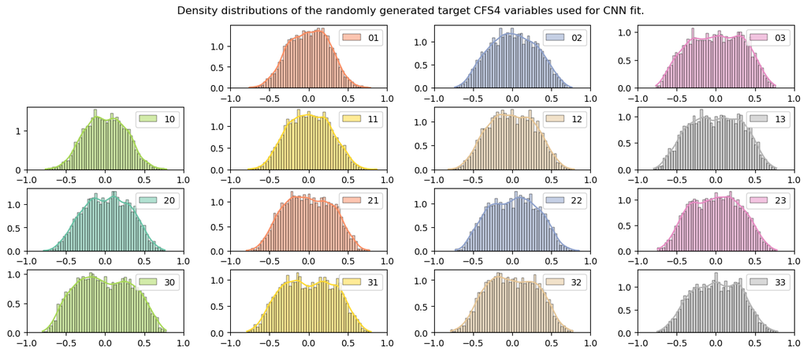

```python
palette = sns.color_palette("Set2", n_colors=16)
rows,cols =4,4
fig, axes = plt.subplots(rows, cols, figsize=(15,6))
k=0
for i in range(rows):
    for j in range(cols):
        mycol=my_cols[k]
        sns.histplot(ax=axes[i,j], data=df_cfs4_big, x=mycol, bins=50,color=palette[k] , kde=True, stat='density', label='%s'%mycol )
        axes[i,j].set_xlabel(None)
        axes[i,j].set_ylabel(None)
        axes[i,j].set_xlim([-1,1])
        axes[i,j].legend(loc=1)
        k+=1
        if k == len(my_cols): break

fig.suptitle("Density distributions of the randomly generated target CFS4 variables used for CNN fit.", fontsize=12, y=0.95)
plt.subplots_adjust(left=0.1,
                    bottom=0.1,
                    right=0.9,
                    top=0.9,
                    wspace=0.3,
                    hspace=0.3)

axes[0, 0].remove()  # remove unused subplot
# plt.legend()
```

```python
# Open the HDF5 file in read-only mode
with h5py.File('cfs4_image_dataset_5000.h5', 'r') as f:
    # Get a list of dataset names in the HDF5 file
    dataset_names = list(f.keys())

    # Print the names of all datasets
    for name in dataset_names:
        print(name)
    dset=f[dataset_names[0]]
    X1=dset[:]
```

```
cfs4_img_data
```

```python
# Open the HDF5 file in read-only mode
with h5py.File('cfs4_big_image_dataset_5000.h5', 'r') as f:
    # Get a list of dataset names in the HDF5 file
    dataset_names = list(f.keys())

    # Print the names of all datasets
    for name in dataset_names:
        print(name)
    dset=f[dataset_names[0]]
    X2=dset[:]
```

```
cfs4_big_img_data
```

```python
# Open the HDF5 file in read-only mode
with h5py.File('cfs4_big_bin_1.h5', 'r') as f:
    # Get a list of dataset names in the HDF5 file
    dataset_names = list(f.keys())

    # Print the names of all datasets
    for name in dataset_names:
        print(name)
    dset=f[dataset_names[0]]
    X3a=dset[:]
```

```
cfs4_big_bin_1
```

[output not shown]

```python
# read in  the correlation datum
df_cfs4b3a=pd.read_csv('cfs4_big_corr_out_1.csv')
df_cfs4b3a=df_cfs4b3a.drop('Unnamed: 0',axis=1)
df_cfs4b3a.reset_index(inplace=True,drop=True)
df_cfs4b3a.head()
```

|  | 00 | 01 | 02 | 03 | 10 | 11 | 12 | 13 | 20 | 21 | 22 | 23 | 30 | 31 | 32 | 33 |
| --- | --- | --- | --- | --- | --- | --- | --- | --- | --- | --- | --- | --- | --- | --- | --- | --- |
| 0 | 0.999963 | -0.194047 | 0.068539 | -0.276947 | -0.054724 | 0.128001 | 0.201352 | 0.152307 | 0.249963 | 0.212203 | -0.180158 | -0.223995 | -0.130245 | 0.503869 | -0.067311 | 0.144928 |
| 1 | 0.999635 | -0.185695 | 0.109010 | -0.193941 | 0.268299 | 0.111180 | -0.179184 | -0.441771 | 0.321250 | 0.242257 | 0.343819 | -0.366684 | -0.203490 | -0.072847 | 0.324288 | -0.449583 |
| 2 | 0.999994 | -0.059468 | -0.047315 | -0.403217 | 0.317703 | -0.270839 | -0.026915 | -0.567280 | -0.298183 | -0.128912 | -0.287332 | -0.198790 | -0.332037 | 0.055116 | -0.503044 | 0.397998 |
| 3 | 0.999999 | -0.035591 | -0.029949 | 0.048610 | -0.033421 | 0.157985 | -0.015192 | -0.733508 | 0.664495 | 0.013020 | 0.234808 | -0.000001 | 0.099825 | 0.266926 | -0.082032 | -0.508248 |
| 4 | 0.999852 | -0.174627 | 0.422161 | 0.034141 | 0.417387 | -0.653360 | 0.372248 | -0.203707 | -0.070460 | -0.676797 | 0.380929 | -0.600408 | 0.142213 | -0.163776 | 0.468602 | -0.566120 |

```python
y3a=df_cfs4b3a.iloc[:,1:16].values
```

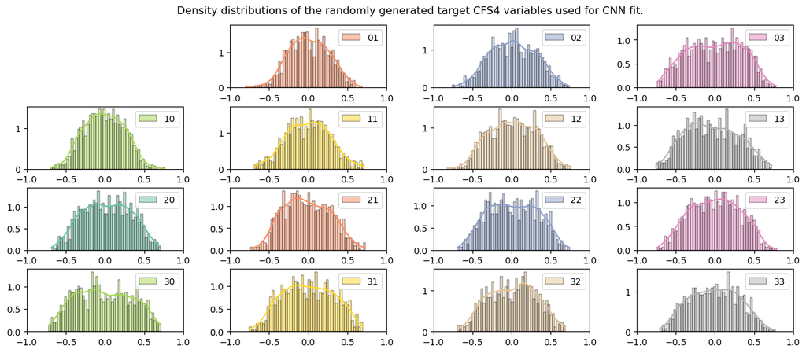

```python
check_cfs_dist(df_cfs4b3a,cfs=4)
```

# old code to read data directly from binfiles N=10 # rad this many images Nstart=0 # start labels here imdats=[] for i in range(N): imb = read_bin('./image_inputs_bin/hk0_%s.bin'%str(i+Nstart).zfill(6), npixels=64, offset=1280) imdats.append(imb) imdats=np.vstack(imdats) imdats=imdats.reshape((10,64,64)) print(np.shape(imdats))

```python
print(np.shape(y1))
print(np.shape(y2))
print(np.shape(X1))
print(np.shape(X2))
```

```
(5000, 15)
(5000, 15)
(5000, 64, 64)
(5000, 64, 64)
```

```python
X12=np.r_[X1,X2]
y12=np.r_[y1,y2]
print(np.shape(y12))
print(np.shape(X12))
```

```
(10000, 15)
(10000, 64, 64)
```

```python
X_train12, X_test12, y_train12, y_test12 = train_test_split(X12, y12, random_state=42,test_size=0.2)
X_train1, X_test1, y_train1, y_test1 = train_test_split(X1, y1, random_state=42,test_size=0.2)
X_train2, X_test2, y_train2, y_test2 = train_test_split(X2, y2, random_state=42,test_size=0.2)

X_train12=np.expand_dims(X_train12, -1)
X_test12=np.expand_dims(X_test12, -1)
X_train1=np.expand_dims(X_train1, -1)
X_test1=np.expand_dims(X_test1, -1)
X_train2=np.expand_dims(X_train2, -1)
X_test2=np.expand_dims(X_test2, -1)

print(np.shape(X_train1),type(X_train1))
print(np.shape(X_test1),type(X_test1))
print(np.shape(y_train1),type(y_train1))
print(np.shape(y_test1),type(y_test1))
```

[output not shown]

```python
import plotly.express as px
num_img_to_sample = 10
random_img = np.random.choice(X1.shape[0], size=num_img_to_sample, replace=False)
sampled_img = X1[random_img]
fig = px.imshow(sampled_img, binary_string=True, animation_frame=0, zmax=4)
fig.show()
```

[interactive chart not shown]

```python
import plotly.express as px
num_img_to_sample = 10
random_img = np.random.choice(X2.shape[0], size=num_img_to_sample, replace=False)
sampled_img = X2[random_img]
fig = px.imshow(sampled_img, binary_string=True, animation_frame=0, zmax=4)
fig.show()
```

[interactive chart not shown]

## done some more EDA on the actual data so that we can get some idea of predictive power but also

## exactly how sensitive is the model is to outliers

### the below histogram means that any data fed into the model

### should roughly scale with the same distribution of intensities

the best way to do this is might be to just draw a straight line through the logplot version of the histogram sicne there is information that is so weak it is less useful

```
0.25179419209412757
0.08077490702271461
42.968379974365234
0.0021034684032201767
```

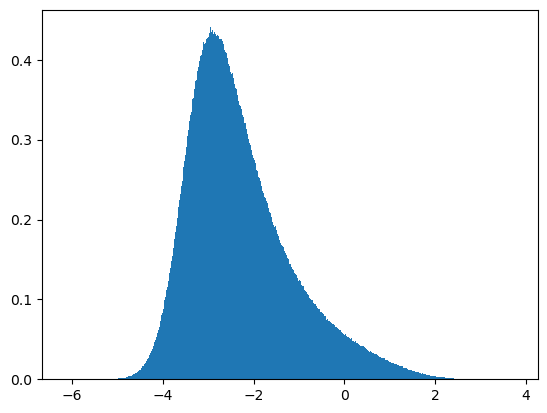

```python
ax=plt.hist(np.log(X1.flatten()),bins=1000,log=False,density=True)
print(np.mean(X1.flatten()))
print(np.median(X1.flatten()))
print(np.max(X1.flatten()))
print(np.min(X1.flatten()))
```

```
0.25278253299105474
0.06955553218722343
54.31019592285156
0.005550937261432409
```

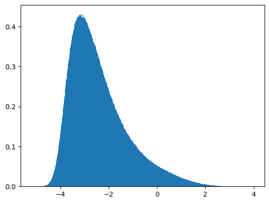

```python
ax=plt.hist(np.log(X2.flatten()),bins=1000,log=False,density=True)
print(np.mean(X2.flatten()))
print(np.median(X2.flatten()))
print(np.max(X2.flatten()))
print(np.min(X2.flatten()))
```

```
0.2529564511049806
0.06906754150986671
46.27295684814453
0.005566991399973631
```

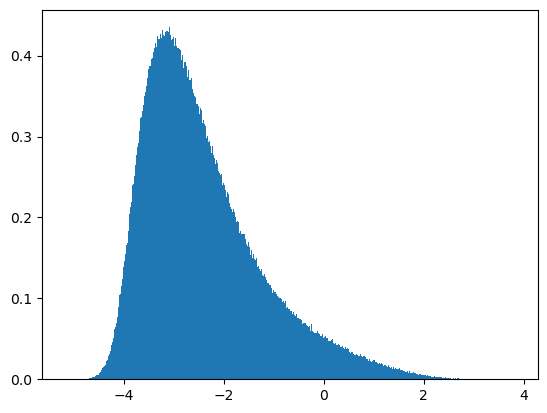

```python
ax=plt.hist(np.log(X3a.flatten()),bins=1000,log=False,density=True)
print(np.mean(X3a.flatten()))
print(np.median(X3a.flatten()))
print(np.max(X3a.flatten()))
print(np.min(X3a.flatten()))
```

# Design the small model CNN

```python
# original model

input_shape = (64, 64, 1)
model_sm = keras.Sequential(
    [
        keras.Input(shape=input_shape),
        layers.Conv2D(32, kernel_size=(3, 3), activation="relu",name='conv1'),
        layers.BatchNormalization(name='norm1'),
        layers.MaxPooling2D(pool_size=(2, 2),name='maxpool1'),
        layers.Dropout(0.2,name='drop1'),


        layers.Conv2D(64, kernel_size=(3, 3), activation="relu",name='conv2'),
        layers.BatchNormalization(name='norm2'),
        layers.MaxPooling2D(pool_size=(2, 2),name='maxpool2'),


        layers.Flatten(name='flatten1'),
        layers.Dropout(0.5,name='drop2'),
        layers.Dense(15, activation="linear",name='dense_out'),
    ],name='seq_CNN_cfs4'
)

model_sm.summary()
```

```
Model: "seq_CNN_cfs4"
_________________________________________________________________
 Layer (type)                Output Shape              Param #
=================================================================
 conv1 (Conv2D)              (None, 62, 62, 32)        320

 norm1 (BatchNormalization)  (None, 62, 62, 32)        128

 maxpool1 (MaxPooling2D)     (None, 31, 31, 32)        0

 drop1 (Dropout)             (None, 31, 31, 32)        0

 conv2 (Conv2D)              (None, 29, 29, 64)        18496

 norm2 (BatchNormalization)  (None, 29, 29, 64)        256

 maxpool2 (MaxPooling2D)     (None, 14, 14, 64)        0

 flatten1 (Flatten)          (None, 12544)             0

 drop2 (Dropout)             (None, 12544)             0

 dense_out (Dense)           (None, 15)                188175

=================================================================
Total params: 207,375
Trainable params: 207,183
Non-trainable params: 192
_________________________________________________________________
```

# Design the medium model CNN

```python
from keras.initializers import HeNormal as he_normal
inputs = keras.Input(shape=(64, 64, 1))

#First block with downsampling
x1 = layers.Conv2D(filters=32, kernel_size=(3, 3), activation='relu', padding='same', kernel_initializer=he_normal())(inputs)
x1 = layers.BatchNormalization()(x1)
x1 = layers.Conv2D(filters=64, kernel_size=(3, 3), activation='relu', padding='same', kernel_initializer=he_normal(), strides=2)(x1)  # Downsample with stride=2
x1 = layers.BatchNormalization()(x1)
x1 = layers.MaxPooling2D(pool_size=(2, 2))(x1)
x1 = layers.Dropout(0.2)(x1)


#Second block with skip connection
x2 = layers.Conv2D(filters=64, kernel_size=(3, 3), activation='relu', padding='same', kernel_initializer=he_normal())(x1)
x2 = layers.BatchNormalization()(x2)
x2 = layers.MaxPooling2D(pool_size=(2, 2))(x2)
x2 = layers.Dropout(0.25)(x2)
x2 = layers.Conv2D(filters=128, kernel_size=(3, 3), activation='relu', padding='same', kernel_initializer=he_normal())(x2)
x2 = layers.BatchNormalization()(x2)

x1_downsampled = layers.Conv2D(filters=128, kernel_size=(3, 3), activation='relu', padding='same', kernel_initializer=he_normal(), strides=2)(x1)  #Downsample with stride=2
x2 = layers.Add()([x2, x1_downsampled])  #Add skip connection
x2 = layers.Activation('relu')(x2)
x2 = layers.Dropout(0.25)(x2)

# route to Dense Block
x3 = layers.Flatten()(x2)
x3 = layers.Dense(units=128, activation="relu", kernel_initializer=he_normal())(x3)
x3 = layers.BatchNormalization()(x3)
x3 = layers.Dropout(0.5)(x3)
x3 = layers.Dense(units=15, activation='linear', kernel_initializer=he_normal())(x3)
model_md = keras.Model(inputs=inputs, outputs=x3)

model_md.summary()
```

```
Model: "model_2"
__________________________________________________________________________________________________
 Layer (type)                   Output Shape         Param #     Connected to
==================================================================================================
 input_6 (InputLayer)           [(None, 64, 64, 1)]  0           []

 conv2d_33 (Conv2D)             (None, 64, 64, 32)   320         ['input_6[0][0]']

 batch_normalization_27 (BatchN  (None, 64, 64, 32)  128         ['conv2d_33[0][0]']
 ormalization)

 conv2d_34 (Conv2D)             (None, 32, 32, 64)   18496       ['batch_normalization_27[0][0]']

 batch_normalization_28 (BatchN  (None, 32, 32, 64)  256         ['conv2d_34[0][0]']
 ormalization)

 max_pooling2d_9 (MaxPooling2D)  (None, 16, 16, 64)  0           ['batch_normalization_28[0][0]']

 dropout_24 (Dropout)           (None, 16, 16, 64)   0           ['max_pooling2d_9[0][0]']

 conv2d_35 (Conv2D)             (None, 16, 16, 64)   36928       ['dropout_24[0][0]']

 batch_normalization_29 (BatchN  (None, 16, 16, 64)  256         ['conv2d_35[0][0]']
 ormalization)

 max_pooling2d_10 (MaxPooling2D  (None, 8, 8, 64)    0           ['batch_normalization_29[0][0]']
 )

 dropout_25 (Dropout)           (None, 8, 8, 64)     0           ['max_pooling2d_10[0][0]']

 conv2d_36 (Conv2D)             (None, 8, 8, 128)    73856       ['dropout_25[0][0]']

 batch_normalization_30 (BatchN  (None, 8, 8, 128)   512         ['conv2d_36[0][0]']
 ormalization)

 conv2d_37 (Conv2D)             (None, 8, 8, 128)    73856       ['dropout_24[0][0]']

 add_9 (Add)                    (None, 8, 8, 128)    0           ['batch_normalization_30[0][0]',
                                                                  'conv2d_37[0][0]']

 activation_9 (Activation)      (None, 8, 8, 128)    0           ['add_9[0][0]']

 dropout_26 (Dropout)           (None, 8, 8, 128)    0           ['activation_9[0][0]']

 flatten_3 (Flatten)            (None, 8192)         0           ['dropout_26[0][0]']

 dense_5 (Dense)                (None, 128)          1048704     ['flatten_3[0][0]']

 batch_normalization_31 (BatchN  (None, 128)         512         ['dense_5[0][0]']
 ormalization)

 dropout_27 (Dropout)           (None, 128)          0           ['batch_normalization_31[0][0]']

 dense_6 (Dense)                (None, 15)           1935        ['dropout_27[0][0]']

==================================================================================================
Total params: 1,255,759
Trainable params: 1,254,927
Non-trainable params: 832
__________________________________________________________________________________________________
```